# Pinto: Spatial Transcriptomics Analysis

## Prepare spatially-resolved transcriptomic data

- We can download [10x Genomics Xenium Prime Ovarian Cancer FFPE data](https://www.10xgenomics.com/datasets/xenium-prime-ffpe-human-ovarian-cancer) (Note: This is a large zip file).
- Convert the 10x Xenium `.zarr.zip` matrix into a `.zarr` backend that pinto can read efficiently.

```bash
mkdir -p temp
if ! [ -d temp/data.zarr ] ; then
    [ -f Xenium_Prime_Ovarian_Cancer_FFPE_XRrun_xe_outs.zip ] || \
        curl -O https://cf.10xgenomics.com/samples/xenium/3.0.0/Xenium_Prime_Ovarian_Cancer_FFPE_XRrun/Xenium_Prime_Ovarian_Cancer_FFPE_XRrun_xe_outs.zip
    unzip Xenium_Prime_Ovarian_Cancer_FFPE_XRrun_xe_outs.zip -d temp
    data-beans from-zarr temp/cell_feature_matrix.zarr.zip \
        --backend zarr \
        --do-squeeze \
        --row-nnz-cutoff 10 \
        --column-nnz-cutoff 10 \
        --output temp/data
fi
```

- Alternatively, pinto can auto-convert on the fly (creates `{file}.db.zarr` next to the input), but pre-converting avoids repeated work across runs.

## Run delta-SVD

- Delta-SVD decomposes cell-cell edge profiles into shared and difference channels, then finds latent topics via randomized SVD.

```bash
[ -f temp/dsvd.latent.parquet ] || \
    pinto dsvd temp/data.zarr \
    --coord temp/cells.zarr.zip \
    --coord-column-names cell_centroid_x,cell_centroid_y \
    -d 1024 \
    -t 7 --preload-data \
    -o temp/dsvd
```

This produces:

| Output file | Description |
| --- | --- |
| `dsvd.coord_pairs.parquet` | Spatial coordinates for each cell pair (edge) |
| `dsvd.basis.parquet` | SVD basis vectors (gene loadings, `@shared` / `@diff` suffixes) |
| `dsvd.latent.parquet` | Latent edge representations (L2-normalized) |
| `dsvd.propensity.parquet` | Soft cell-to-topic membership |
| `dsvd.gene_topic.parquet` | Per-topic gene expression rates |
| `dsvd.edge_cluster.parquet` | Edge-to-cluster assignments |

## Run link community model

- The link community model assigns each edge to one of K communities via collapsed Gibbs sampling on a Poisson-Gamma model, using multi-level coarsening for scalability.

```bash
[ -f temp/lc.propensity.parquet ] || \
    pinto lc temp/data.zarr \
    --coord temp/cells.zarr.zip \
    --coord-column-names cell_centroid_x,cell_centroid_y \
    -d 1024 --preload-data --reciprocal \
    --n-communities 7 \
    --num-sweeps 10 \
    -k 10 \
    -o temp/lc
```

This produces:

| Output file | Description |
| --- | --- |
| `lc.coord_pairs.parquet` | Spatial coordinates for each cell pair (edge) |
| `lc.propensity.parquet` | Soft cell-to-community membership |
| `lc.gene_topic.parquet` | Per-community gene expression rates |
| `lc.gene_modules.parquet` | Gene-to-module assignments (K-means on gene sketches) |
| `lc.link_community.parquet` | Edge-to-community assignments |
| `lc.scores.parquet` | Gibbs sampling score trace per coarsening level |

## Visualize results in R

```r
library(arrow)
library(data.table)
library(ggplot2)
library(patchwork)

theme_set(theme_minimal(base_size = 12))
```

### Load delta-SVD results

```r
dsvd_prop <- as.data.table(read_parquet("temp/dsvd.propensity.parquet"))
dsvd_gene <- as.data.table(read_parquet("temp/dsvd.gene_topic.parquet"))
dsvd_basis <- as.data.table(read_parquet("temp/dsvd.basis.parquet"))
```

### Load link community results

```r
lc_prop <- as.data.table(read_parquet("temp/lc.propensity.parquet"))
lc_gene <- as.data.table(read_parquet("temp/lc.gene_topic.parquet"))
lc_links <- as.data.table(read_parquet("temp/lc.link_community.parquet"))
lc_scores <- as.data.table(read_parquet("temp/lc.scores.parquet"))
```

### Load coordinates

```r
coords <- as.data.table(read_parquet("temp/cells.parquet"))
```

### Delta-SVD: cell topic map

```r
library(dplyr)
.dsvd <- dsvd_prop %>%
    as.data.table() %>%
    melt(id.vars = c("cell", "cluster"), variable.name = "topic_label") %>%
    filter(value > .1) %>%
    rename(cell_id = cell) %>%
    left_join(coords) %>%
    na.omit() %>%
    as.data.table()
```

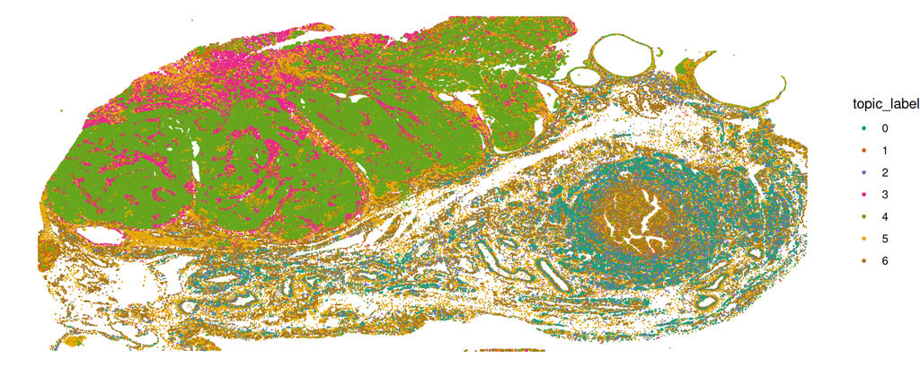

```r
.aes <- aes(x = cell_centroid_x,
            y = cell_centroid_y,
            colour = topic_label,
            size = value)

ggplot(.dsvd, .aes) +
    theme_void() +
    scale_size_continuous(range=c(0, 0.5), guide="none") +
    ggrastr::rasterize(geom_point(stroke = 0.0),dpi=300) +
    scale_colour_brewer(palette="Dark2") +
    scale_y_reverse()
```

### Delta-SVD: top genes per topic

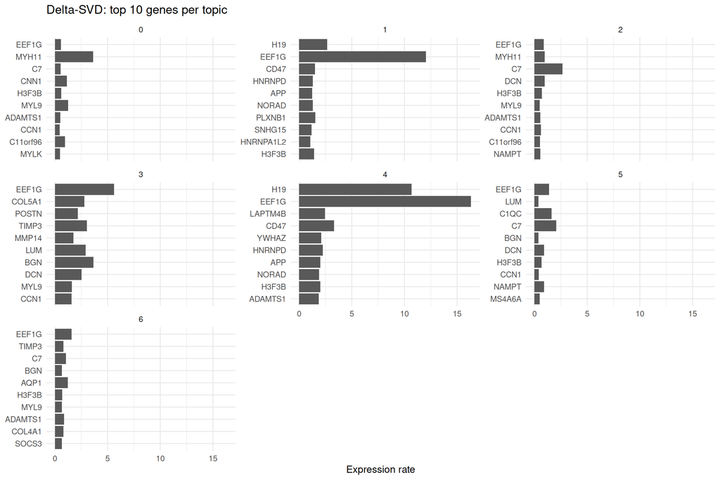

```r
# gene_topic is long format: row (gene), column (topic), mean, sd, log_mean
dsvd_gene[, gene := sub("^[^_]+_", "", row)]

top_genes <- dsvd_gene[, .SD[order(-mean)][1:10], by = column]

ggplot(top_genes, aes(x = reorder(gene, mean), y = mean)) +
    geom_col() +
    coord_flip() +
    facet_wrap(~ column, scales = "free_y") +
    labs(title = "Delta-SVD: top 10 genes per topic",
         x = NULL, y = "Expression rate")
```

Based on the top marker genes, the delta-SVD topics correspond to major cell populations in the ovarian cancer tumour microenvironment:

| Topic | Top markers | Interpretation |
| --- | --- | --- |
| 0 | MYH11, MYL9, CNN1 | Smooth muscle cells |
| 1 | H19, PLXNB1, CD47, NORAD | Tumour epithelial cells |
| 2 | C7, DCN, CCN1 | Stromal / immune interface |
| 3 | BGN, LUM, COL5A1, DCN, POSTN | Desmoplastic stroma / cancer-associated fibroblasts (CAFs) |
| 4 | H19, CD47, LAPTM4B, YWHAZ | Tumour cells (overlaps topic 1) |
| 5 | C1QC, C7, MS4A6A | Macrophages / myeloid cells |
| 6 | AQP1, COL4A1, ADAMTS1 | Endothelium / vasculature |

### Link community: cell membership map

```r
.lc <- melt(lc_prop, id.vars = "cell", variable.name = "community", value.name = "value") %>%
    filter(value > .1) %>%
    rename(cell_id = cell) %>%
    left_join(coords) %>%
    na.omit() %>%
    as.data.table()
```

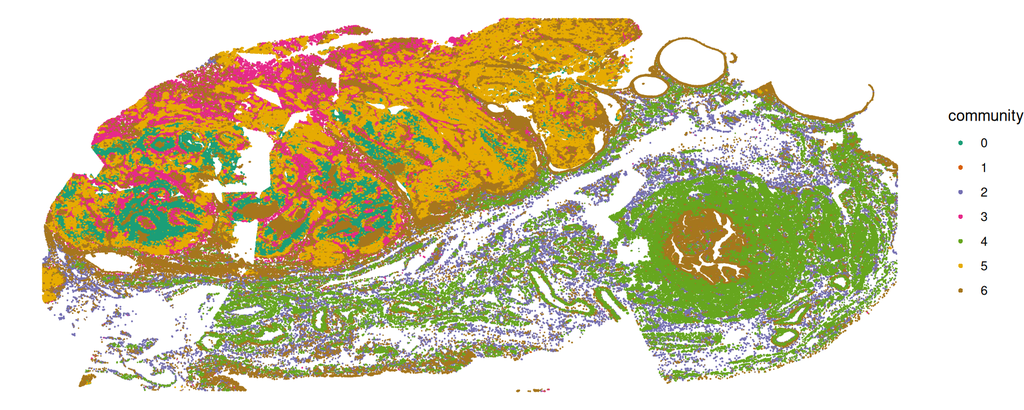

```r
ggplot(.lc, aes(x = cell_centroid_x, y = cell_centroid_y, colour = community, size = value)) +
    theme_void() +
    scale_size_continuous(range = c(0, 0.5), guide="none") +
    ggrastr::rasterize(geom_point(stroke = 0.0), dpi = 300) +
    scale_colour_brewer(palette = "Dark2") +
    scale_y_reverse()
```

### Link community: top genes per community

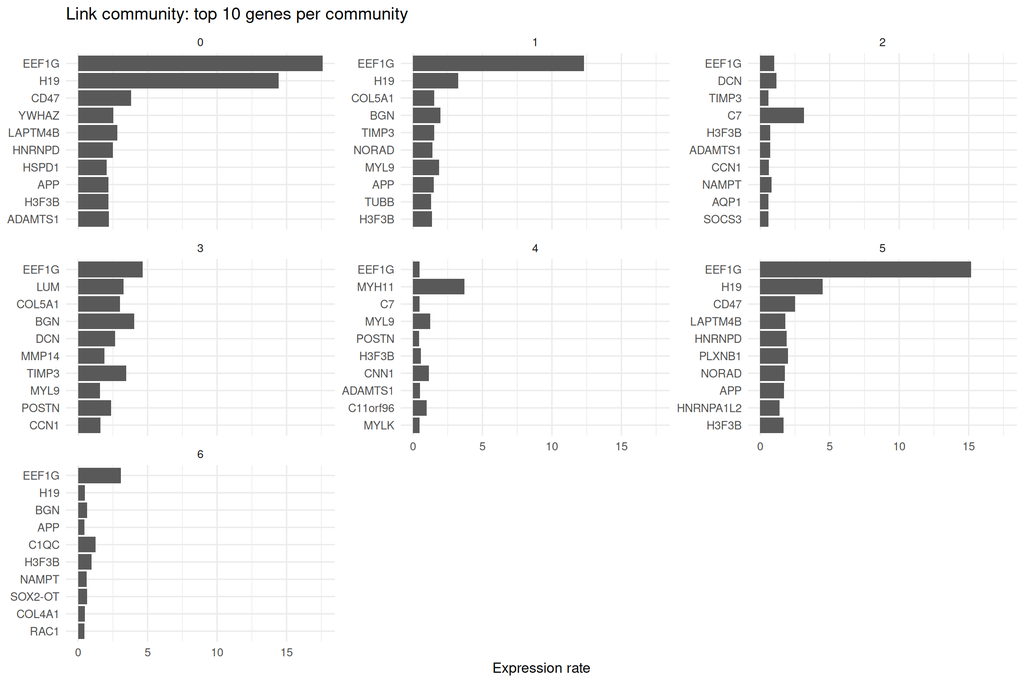

```r
# gene_topic is long format: row (gene), column (community), mean, sd, log_mean
lc_gene[, gene := sub("^[^_]+_", "", row)]

lc_top <- lc_gene[, .SD[order(-mean)][1:10], by = column]

ggplot(lc_top, aes(x = reorder(gene, mean), y = mean)) +
    geom_col() +
    coord_flip() +
    facet_wrap(~ column, scales = "free_y") +
    labs(title = "Link community: top 10 genes per community",
         x = NULL, y = "Expression rate")
```

The link communities are broadly concordant with the delta-SVD topics, capturing the same major compartments of the tumour microenvironment:

| Community | Top markers | Interpretation |
| --- | --- | --- |
| 0 | H19, CD47, LAPTM4B, YWHAZ | Tumour cells |
| 1 | MYL9, BGN, TIMP3, COL5A1 | Mixed stromal / myofibroblast |
| 2 | C7, DCN, NAMPT, ADAMTS1 | Stromal / immune-rich zone |
| 3 | BGN, LUM, COL5A1, DCN, POSTN | Desmoplastic stroma / CAFs |
| 4 | MYH11, MYL9, CNN1 | Smooth muscle cells |
| 5 | H19, CD47, PLXNB1, NORAD | Tumour epithelial cells |
| 6 | C1QC, NAMPT, COL4A1 | Macrophage-enriched niche |